# Makefile

Elizabeth Ramsdell

October 27, 2016

## Introduction

This is a research project on the GDP and GDP ranking of different countries and how income group segments this.

To do this, first, 2 data sets need to be merged in order to get all the variables necessary. Then, during exploratory analysis, I have looked at where certain countries rank among the others. I have also researched the average GDP rankings for the high income groups.

To visualize the results of GDP vs Income Group, a scatterplot and a table displaying the relationship has been included.

## Importing the datasets

```r
setwd("~/Doing Data Science/CaseStudy1/Data")
source("ImportData.R")
```

## Explore, Clean and Merge Data

```r
str(GDP)
```

```
## 'data.frame':    190 obs. of  5 variables:
##  $ CountryCode: chr  "USA" "CHN" "JPN" "DEU" ...
##  $ Ranking    : int  1 2 3 4 5 6 7 8 9 10 ...
##  $ Economy    : chr  "United States" "China" "Japan" "Germany" ...
##  $ US.dollars.: chr  "16,244,600" "8,227,103" "5,959,718" "3,428,131" ...
##  $ X          : chr  "" "" "" "" ...
```

```r
str(Education)
```

```
## 'data.frame':    234 obs. of  31 variables:
##  $ CountryCode                                      : chr  "ABW" "ADO" "AFG" "AGO" ...
##  $ Long.Name                                        : chr  "Aruba" "Principality of Andorra" "Islamic State of Afghanistan" "People's Republic of Angola" ...
##  $ Income.Group                                     : chr  "High income: nonOECD" "High income: nonOECD" "Low income" "Lower middle income" ...
##  $ Region                                           : chr  "Latin America & Caribbean" "Europe & Central Asia" "South Asia" "Sub-Saharan Africa" ...
##  $ Lending.category                                 : chr  "" "" "IDA" "IDA" ...
##  $ Other.groups                                     : chr  "" "" "HIPC" "" ...
##  $ Currency.Unit                                    : chr  "Aruban florin" "Euro" "Afghan afghani" "Angolan kwanza" ...
##  $ Latest.population.census                         : chr  "2000" "Register based" "1979" "1970" ...
##  $ Latest.household.survey                          : chr  "" "" "MICS, 2003" "MICS, 2001, MIS, 2006/07" ...
##  $ Special.Notes                                    : chr  "" "" "Fiscal year end: March 20; reporting period for national accounts data: FY." "" ...
##  $ National.accounts.base.year                      : chr  "1995" "" "2002/2003" "1997" ...
##  $ National.accounts.reference.year                 : int  NA NA NA NA 1996 NA NA 1996 NA NA ...
##  $ System.of.National.Accounts                      : int  NA NA NA NA 1993 NA 1993 1993 NA NA ...
##  $ SNA.price.valuation                              : chr  "" "" "VAB" "VAP" ...
```

[output cut: 17 more lines]

US.dollars. is character and has commas. Change US.dollars. variable in GDP and rename

```r
GDP$USDollars <- as.numeric(gsub(",","",GDP$US.dollars.))
```

Merge the GDP and Education Datasets and Save Change all variable names to lower case

```r
MergeData <- merge(x=GDP, y=Education, by="CountryCode")

write.csv(MergeData,"MergeData")

names(MergeData) <- tolower(names(MergeData))
```

# 1. How many of the IDs match?

### 189

```r
str(MergeData)
```

```
## 'data.frame':    189 obs. of  36 variables:
##  $ countrycode                                      : chr  "ABW" "AFG" "AGO" "ALB" ...
##  $ ranking                                          : int  161 105 60 125 32 26 133 172 12 27 ...
##  $ economy                                          : chr  "Aruba" "Afghanistan" "Angola" "Albania" ...
##  $ us.dollars.                                      : chr  "2,584" "20,497" "114,147" "12,648" ...
##  $ x                                                : chr  "" "" "" "" ...
##  $ usdollars                                        : num  2584 20497 114147 12648 348595 ...
##  $ long.name                                        : chr  "Aruba" "Islamic State of Afghanistan" "People's Republic of Angola" "Republic of Albania" ...
##  $ income.group                                     : chr  "High income: nonOECD" "Low income" "Lower middle income" "Upper middle income" ...
##  $ region                                           : chr  "Latin America & Caribbean" "South Asia" "Sub-Saharan Africa" "Europe & Central Asia" ...
##  $ lending.category                                 : chr  "" "IDA" "IDA" "IBRD" ...
##  $ other.groups                                     : chr  "" "HIPC" "" "" ...
##  $ currency.unit                                    : chr  "Aruban florin" "Afghan afghani" "Angolan kwanza" "Albanian lek" ...
##  $ latest.population.census                         : chr  "2000" "1979" "1970" "2001" ...
##  $ latest.household.survey                          : chr  "" "MICS, 2003" "MICS, 2001, MIS, 2006/07" "MICS, 2005" ...
```

[output cut: 22 more lines]

# 2. Sort the data frame in ascending order by GDP, What is the 13th country in the resulting data frame?

### 13th Country in ordered data is St. Kitts and Nevis

```r
OrderByGDP <- MergeData[order(MergeData$usdollars),]

OrderByGDP[1][13,]
```

```
## [1] "KNA"
```

```r
KDPName <- subset(MergeData, countrycode == "KNA")
KDPName
```

```
##    countrycode ranking             economy us.dollars. x usdollars
## 93         KNA     178 St. Kitts and Nevis         767         767
##              long.name        income.group                    region
## 93 St. Kitts and Nevis Upper middle income Latin America & Caribbean
##    lending.category other.groups         currency.unit
## 93             IBRD              East Caribbean dollar
##    latest.population.census latest.household.survey special.notes
## 93                     2001
##    national.accounts.base.year national.accounts.reference.year
## 93                        1990                               NA
##    system.of.national.accounts sna.price.valuation
## 93                        1993                 VAB
##    alternative.conversion.factor ppp.survey.year
## 93                                            NA
##    balance.of.payments.manual.in.use external.debt.reporting.status
## 93                              BPM5                    Preliminary
##    system.of.trade government.accounting.concept
## 93         General                  Consolidated
##    imf.data.dissemination.standard
## 93                            GDDS
##    source.of.most.recent.income.and.expenditure.data
## 93
##    vital.registration.complete latest.agricultural.census
## 93
##    latest.industrial.data latest.trade.data latest.water.withdrawal.data
## 93                     NA              2007                           NA
##    x2.alpha.code wb.2.code          table.name          short.name
## 93            KN        KN St. Kitts and Nevis St. Kitts and Nevis
```

# 3. What are the average GDP rankings for the “High income: OECD” and “High income: nonOECD” groups?

### The average GDP rankings for the High Income OECD group is 32.96

### Average ranking for the High Income Non OECD group is 91.91

```r
unique(MergeData$income.group) ##Check for mispellings
```

```
## [1] "High income: nonOECD" "Low income"           "Lower middle income"
## [4] "Upper middle income"  "High income: OECD"
```

```r
HighIncomeOECD <- subset(MergeData, income.group == "High income: OECD")
mean(HighIncomeOECD$ranking)
```

```
## [1] 32.96667
```

```r
HighIncomeNonOECD <- subset(MergeData, income.group == "High income: nonOECD")
mean(HighIncomeNonOECD$ranking)
```

```
## [1] 91.91304
```

## 5. Cut the GDP Ranking into 5 separate quantile groups

find ranges

```r
189/5
```

```
## [1] 37.8
```

```r
(189/5)*2
```

```
## [1] 75.6
```

```r
(189/5)*3
```

```
## [1] 113.4
```

```r
(189/5)*4
```

```
## [1] 151.2
```

```r
(189/5)*5
```

```
## [1] 189
```

Create Categories

```r
attach(MergeData)
MergeData$rankingcat[ranking <= 37] <- "Low Rank"
MergeData$rankingcat[ranking > 37 & ranking <= 75] <- "Medium Low Rank"
MergeData$rankingcat[ranking > 75 & ranking <= 113] <- "Medium Rank"
MergeData$rankingcat[ranking > 113 & ranking <= 151] <- "Medium High Rank"
MergeData$rankingcat[ranking > 151] <- "High Rank"
detach(MergeData)
```

# 4. Plot GDP by Country

Table and Plot of GDP ranking and income group

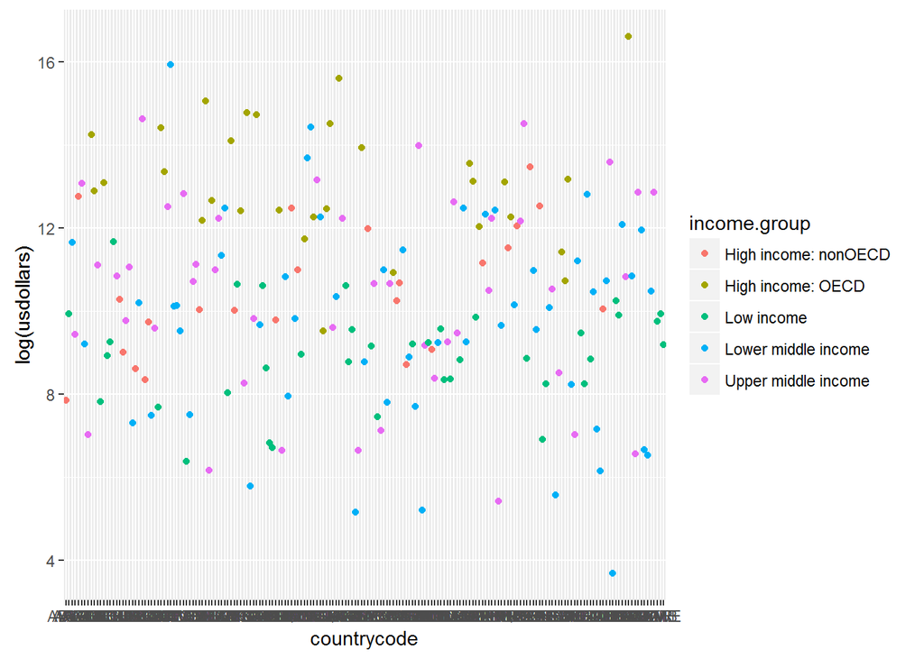

```r
library(ggplot2)
ggplot(MergeData, aes(x=countrycode, y=log(usdollars))) + geom_point(aes(colour=income.group))
```

# 5. Table:Ranking Category vs Income Group

```r
table(MergeData$rankingcat,MergeData$income.group)
```

```
##
##                    High income: nonOECD High income: OECD Low income
##   High Rank                           2                 0         12
##   Low Rank                            4                18          0
##   Medium High Rank                    4                 1         15
##   Medium Low Rank                     5                10          1
##   Medium Rank                         8                 1          9
##
##                    Lower middle income Upper middle income
##   High Rank                         16                   9
##   Low Rank                           4                  11
##   Medium High Rank                   9                   8
##   Medium Low Rank                   14                   8
##   Medium Rank                       11                   9
```

## Summary

#### After merging and cleaning the 2 datasets, we are able to check any trends between GDP and Income Group. The scatter plot is colored by Income Group. Although the HighIncome:OECD group seems to have all of it’s distribution near the top of the graph, the rest of the groups seem evenly spread throughout the graph. This might show that there is not an important relationship between income group and GDP rank within the countries given. The high income non OECD has a larger average than the high income OECD group. Also, the table outlines that the GDP rank may be spread throughout the different income groups, more than one would expect.